# Грицюк Костянтин

## Фінальний проект

Як джерело даних для свого проекту, я обрав дані опитування Behavioral Risk Factor Surveillance System (BRFSS) 2020 року від організації Centers for Disease Control and Prevention (CDC)

Це посилання на самі дані: [Посилання](https://www.cdc.gov/brfss/annual_data/2020/files/LLCP2020XPT.zip)

А це посилання на опис методології опитування: [Посилання](https://www.cdc.gov/brfss/annual_data/2020/pdf/codebook20_llcp-v2-508.pdf)

Для запуску проекту потрібно розархівувати файл "LLCP2020.zip". В ньому знаходиться .csv файл. Оригінальний файл з розширенням .xpt я не додавав

Оскільки "LLCP2020.zip" занадто великий для завантаження на GitHub, я залишаю посилання на нього на Google Drive: [Посилання](https://drive.google.com/file/d/119xz5s5yd9vicMMvWJ7qwCNCT5Npfx-A/view?usp=sharing)

Його можливо знайти за посиланням вище

## ***

```python
import numpy as np
import altair as alt
import geopandas as gpd
import pandas as pd
import matplotlib.pyplot as plt
plt.style.use('ggplot')
plt.rcParams['figure.figsize'] = (16, 9)
plt.rc('xtick', labelsize=15)
```

Нижче я обираю колонки для свого проекту за назвою в початковому наборі даних:

(Це [посилання](https://www.cdc.gov/brfss/annual_data/2020/pdf/codebook20_llcp-v2-508.pdf) на документ де міститься опис кожного поля)

```python
cols = ['x.state',
 'genhlth',
 'sleptim1',
 'marital',
 'employ1', # P35
 'x.totinda',
 'x.raceprv',
 'x.sex',
 'x.ageg5yr',
 'x.bmi5cat',
 'x.chldcnt',
 'x.educag',
 'x.incomg',
 'x.smoker3',
 'x.rfseat2',]
```

Тут я описую словники щоб перетворити категоріальні дані, які позначені як цифри, у текст для кращої передачі змісту

```python
# x.rfseat2
seatbelt_replace = {1: 'Always wears seatbelt', 2: 'Sometimes wear seatbelt', 9: np.nan}

# x.incomg
income_replace = {1:'<15k', 2:'15k-25k', 3:'25k-35k', 4:'35k-50k', 5:'>50k', 9:np.nan}

# x.raceprv
race_replace = {1:'white', 2:'black', 3:'native american', 4:'asian', 5:'pacific islander', 6:'other', 7:'multiracial', 8:'hispanic'}

# x.sex
sex_replace = {1:'male', 2:'female'}

# x.ageg5yr
age_replace = {1:'18-24', 2:'25-29', 3:'30-34', 4:'35-39', 5:'40-44', 6:'45-49', 7:'50-54', 8:'55-59', 9:'60-64', 10:'65-69', 11:'70-74', 12:'75-79', 13:'80+', 14:np.nan}

# genhlth
genhlth_replace = {1: 'Excellent', 2: 'Very good', 3: 'Good', 4: 'Fair', 5: 'Poor', 7: np.nan, 9: np.nan}

# marital
marital_replace = {1: 'Married', 2: 'Divorced', 3: 'Widowed', 4: 'Separated', 5: 'Never married', 6: ' A member of an unmarried couple', 9: 'Refused'}

# x.bmi5cat
bmi5cat_replace = {1: 'Underweight', 2: 'Normal Weight', 3: 'Overweight', 4: 'Obese'}

# x.smoker3
smoke_replace = {1: 'Active Smoker', 2: 'Smokes sometimes', 3: 'Former smoker', 4: 'Never smoked', 9: np.nan}

# x.totinda
employ_replace = {1: 'Employed for wages', 2: 'Self-employed', 3: 'Out of work > 1 year', 4: 'Out of work for < 1 year', 5: 'Homemaker', 6: 'Student', 7: 'Retired', 8: 'Unable to work', 9: np.nan}

# x.educag
education_replace = {1: 'Didn\'t graduate School', 2: 'Graduated School', 3: 'Attended College or Technical School', 4: 'Graduated from College or Technical School', 9: np.nan}
```

Початково, дані, з якими я працюю, були у форматі .xpt (Тобто, були вигружені за допомогою програми SAS)

Для належного перетворення файлу .xpt в .csv, я скористався R кодом з цього [GitHub сховища](https://github.com/winstonlarson/brfss)

Частково, підхід для початкової обробки даних я запозичив також звідти

```python
df = pd.read_csv('LLCP2020.csv')
df = df[cols]
```

```python
df['x.rfseat2'].replace(seatbelt_replace, inplace = True)

df['x.incomg'].replace(income_replace, inplace = True)

df['x.raceprv'].replace(race_replace, inplace = True)

df['x.sex'].replace(sex_replace, inplace = True)

df['x.ageg5yr'].replace(age_replace, inplace = True)

df['genhlth'].replace(genhlth_replace, inplace = True)

df['marital'].replace(marital_replace, inplace = True)

df['x.bmi5cat'].replace(bmi5cat_replace, inplace = True)

df['x.smoker3'].replace(smoke_replace, inplace = True)

df['x.totinda'].replace(employ_replace, inplace = True)

df['x.educag'].replace(education_replace, inplace = True)

# Good Sleep Rate
df['sleep_enough'] = (df['sleptim1'] > 7)*1

df = df.rename(columns={'x.state': 'state'
                  ,'x.raceprv': 'race'
                  ,'x.ageg5yr': 'age'
                  ,'x.sex': 'sex'
                  ,'x.educag': 'education'
                  ,'x.bmi5cat': 'bmi'
                  ,'x.totinda': 'income'
                  ,'x.smoker3': 'smoker'
                  ,'x.rfseat2': 'seat_belt'})
```

```python
df.head()
```

|  | state | genhlth | sleptim1 | marital | employ1 | income | race | sex | age | bmi | x.chldcnt | education | x.incomg | smoker | seat_belt | sleep_enough |
| --- | --- | --- | --- | --- | --- | --- | --- | --- | --- | --- | --- | --- | --- | --- | --- | --- |
| 0 | 1 | Very good | 5.0 | Divorced | 4.0 | Employed for wages | white | female | 55-59 | Underweight | 1 | Graduated from College or Technical School | <15k | Active Smoker | Always wears seatbelt | 0 |
| 1 | 1 | Good | 7.0 | Widowed | 7.0 | Employed for wages | black | female | 65-69 | Overweight | 1 | Graduated from College or Technical School | NaN | NaN | NaN | 0 |
| 2 | 1 | Good | 7.0 | Married | 7.0 | Employed for wages | black | female | 65-69 | NaN | 1 | Attended College or Technical School | >50k | Never smoked | Always wears seatbelt | 0 |
| 3 | 1 | Excellent | 6.0 | Widowed | 5.0 | Self-employed | white | female | 80+ | NaN | 1 | Graduated School | NaN | Never smoked | Always wears seatbelt | 0 |
| 4 | 1 | Very good | 7.0 | Widowed | 7.0 | Employed for wages | white | female | 80+ | Normal Weight | 1 | Graduated from College or Technical School | NaN | Never smoked | Always wears seatbelt | 0 |

```python
health_groups = df.groupby(['genhlth']).agg({'sleep_enough':'mean', 'state': 'count'})
health_groups_lbl = ['Poor', 'Fair', 'Good', 'Very good', 'Excellent']

health_groups = health_groups.reindex(index = health_groups_lbl)
```

## ***

# Візуалізація 1

В цій візуалізації я показую різницю в частці людей, які сплять достатньо, для груп, які відрізняються за станом здоров'я

Головним у виборі візуалізції для цього завдання, було показати рівень хорошо сну в кожній групі. Тобто, кожна група має бути чітко відокремленою та своїми властивостями давати розуміння того чи іншого значення

Групи за рівнем здоров'я розміщені від найгіршого до найкращого щоб відображати інтуїтивне розуміння напряму покращення

Викликом тут є те, що складно показати малі відмінності між групами Якщо не дивитись зблизька, то відмінність в 0.9% між групами "Good" та "Very good" майже непомітна

Та, як на мене, цей спосіб передачі даних в цьому випадку є найкращим

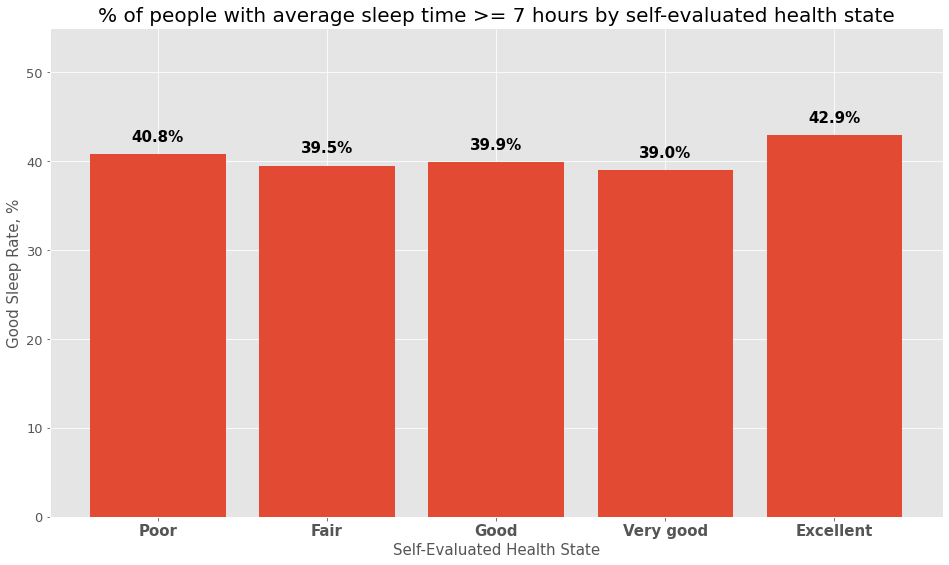

```python
_ = plt.bar(health_groups.index, health_groups['sleep_enough']*100)
_ = plt.xlabel('Self-Evaluated Health State', fontsize=15)
_ = plt.ylabel('Good Sleep Rate, %', fontsize=15)
_ = plt.title('% of people with average sleep time >= 7 hours by self-evaluated health state', fontsize=20)
_ = plt.ylim(0, 55)
_ = plt.xticks(weight='bold')
_ = plt.yticks(size = 13)

for x,y in zip(health_groups.index, health_groups['sleep_enough']*100):
    u = str(health_groups['sleep_enough'].loc[x])
    label = '{:.1f}%'.format(y)

    plt.annotate(label, (x,y), textcoords='offset points', xytext=(0, 13), ha='center', fontsize=15, fontweight='bold')

plt.show()
```

```python
health_educ_groups = df.groupby(['genhlth', 'education'])['state'].count().astype('float')
for g in health_groups_lbl:
    sub_total = health_educ_groups[g].sum()
    for i in health_educ_groups[g].index:
        health_educ_groups[g][i] /= sub_total

health_educ_groups = health_educ_groups.unstack(level=1).reindex(index = health_groups_lbl)*100
health_educ_groups.columns = ["Didn't graduate School",'Graduated School'
                              ,'Attended College or Technical School', 'Graduated from College or Technical School']
```

## ***

# Візуалізація 2

Якщо на попередньому малюнку було розглянути рівень хорошого сну в різних групах за станом здоров'я, то тут я розглядаю структуру цих самих груп за рівнем освіти

На мій погляд, хорошим рішенням відображення структури різних груп є stacked bar chart, де кожен прямокутник в стовпчику своїм розмірои показує частку певної групи в цьому стовпчику

Таким чином одночасно вирішуються дві задачі:

1. Чітко показана структура кожної групи
2. Досить просто відстежити зміну частки певної категорії від стовпця до стовпця

Недоліком такого підходу є складність відображення структури стовпця, який має багато складових

Тоді розмір кожного підпрямокутника буде дуже малим та неінформативним

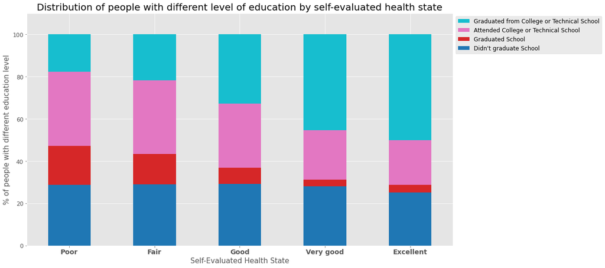

```python
_ = health_educ_groups.plot(kind = 'bar'
                       ,stacked = True
                       ,colormap = 'tab10')

_ = plt.xlabel('Self-Evaluated Health State', fontsize=15)
_ = plt.ylabel('% of people with different education level', fontsize=15)
_ = plt.title('Distribution of people with different level of education by self-evaluated health state', fontsize=20)
_ = plt.ylim(0, 110)
_ = plt.xticks(weight='bold', rotation=0, fontsize=14)
_ = plt.yticks(fontsize=12)

handles, labels = plt.gca().get_legend_handles_labels()

_ = plt.legend([h for h in handles[::-1]]
               ,[l for l in labels[::-1]]
               ,bbox_to_anchor=(1,1)
               ,loc="upper left"
               ,fontsize= 12)

plt.show()
```

```python
edu_groups = df.groupby(['education']).agg({'sleep_enough':'mean'})
edu_groups_lbl = health_educ_groups.columns

edu_groups = edu_groups.reindex(index = edu_groups_lbl)
```

## ***

# Візуалізація 3

На двох попередніх малюнках ми побачили дві картини:

1. Люди з рівнем здоров'я "Excellent" сплять найбільше
2. Серед людей з рівнем здоров'я "Excellent" найбільше тих, хто має вищу освіту

Тепер я хочу перевірити наступну гіпотезу:

Чи є правдою те, що ті, хто мають вищу освіту, сплять найбільше?

Малюнок, отриманий в результаті, дає наступну відповідь:

Ні, люди, які мають вищу освіту, не сплять найбільше

Більше того - вони сплять найменше серед усіх

Як спосіб візуалізації, тут я обрав той самий підхід, що й у першому випадку

Тому деталі цього підходу також не буду розписувати

Лише скажу, що групи за рівнем освіти також розміщені від найгіршого до найкращого

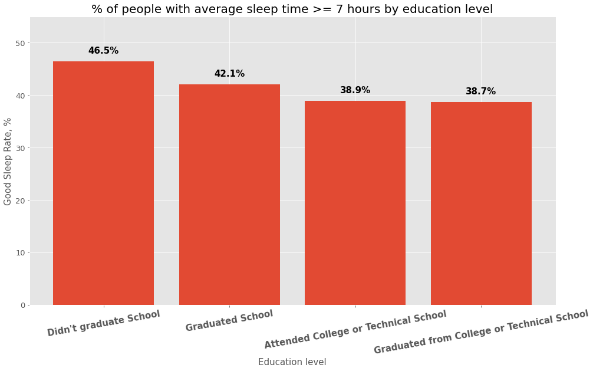

```python
_ = plt.bar(edu_groups.index, edu_groups['sleep_enough']*100)
_ = plt.xlabel('Education level', fontsize=15)
_ = plt.ylabel('Good Sleep Rate, %', fontsize=15)
_ = plt.title('% of people with average sleep time >= 7 hours by education level', fontsize=20)
_ = plt.ylim(0, 55)
_ = plt.xticks(weight='bold', rotation = 10)
_ = plt.yticks(size = 13)

for x,y in zip(edu_groups.index, edu_groups['sleep_enough']*100):
    u = str(edu_groups['sleep_enough'].loc[x])
    label = '{:.1f}%'.format(y)

    plt.annotate(label, (x,y), textcoords='offset points', xytext=(0, 13), ha='center', fontsize=15, fontweight='bold')

plt.show()
```

```python
bmi_smoke_groups = df.groupby(['bmi', 'smoker']
          ).agg({'sleep_enough': 'mean'
                 ,'state':'count'}
          ).rename(columns={'sleep_enough': 'sleep_rate'
                            ,'state':'group_size'}
          )

bmi_ordered = ['Underweight', 'Normal Weight', 'Overweight', 'Obese']
smoke_ordered = ['Active Smoker', 'Smokes sometimes', 'Former smoker', 'Never smoked']

bmi_smoke_groups = bmi_smoke_groups.reindex(bmi_ordered, level=0)
bmi_smoke_groups = bmi_smoke_groups.reindex(smoke_ordered, level=1)

bmi_smoke_groups = bmi_smoke_groups.reset_index(drop=False, inplace = False)
bmi_smoke_groups['sleep_rate'] = np.round(bmi_smoke_groups['sleep_rate']*100, 2)
```

## ***

# Візуалізація 4

На цій візуалізації, я хотів показати залежність рівня хорошого сну від двох факторів - індекс маси тіла та той факт чи є людина курцем чи ні

Для цього я обрав бульбашковий графік. Він підходить через те, що чітко розподіляє кожну пару "ІМТ - куріння" у відповідному місці.

Це спрощує читання та розуміння малюнку

Для кодув#ання рівня сну я обрав кольорову шкалу, де інтуїтивно зрозумілі кольори:

- Зелений - високий рівень сну
- Червоний - низький рівень сну

Також, я розумію, що важливим фактором є розмір кожної групи. Спочатку я хотів закодувавати його розміром. Але це перевантажувало зображення інформацією Тому щоб цього уникнути, я переніс ці дані в tooltip

Також я додав в tooltip власне значення Good Sleep Rate

Можливою складністю прочитання цього малюнку є дещо незвична форма подання. Але, на мою думку, це хороший показати залежність однієї змінної від двох категоріальних властивостей

```python
alt.Chart(bmi_smoke_groups
         ,title = 'Good Sleep Rate by BMI and Smoke addiction'
        ).mark_point(filled = True
        ).encode(
             x = alt.X('bmi:N'
                      ,sort=bmi_ordered[::-1]
                      ,axis = alt.Axis(
                                       labelAngle = 0
                                      ,labelFontSize = 12
                                      ,title = 'Body Mass Index Category')
                      )
            ,y = alt.Y('smoker:N'
                      ,sort=smoke_ordered[::-1]
                      ,axis = alt.Axis(
                                        labelFontSize = 12)
                                       ,title = 'Type of Smokers')
            ,color = alt.Color('sleep_rate:Q'
                              ,scale = alt.Scale(scheme = 'redyellowgreen')
                              ,title = 'Good Sleep Rate, %')
            ,size = alt.value(5000)
#             ,size = alt.Size('group_size:Q'
#                              ,scale = alt.Scale(range = [100, 10000])
#                              ,title = 'Number of Respondents')
            ,tooltip = [
                     alt.Tooltip('sleep_rate:Q', title = 'Good Sleep Rate')
                    ,alt.Tooltip('group_size:Q', title = 'Number of Respondents')
                    ]
        ).properties(width = 660, height = 480
        ).configure_axis(
             titleFontSize=14
        ).configure_title(fontSize=20)
```

[interactive chart not shown]

Для візуалізації карти нижче, я взяв геопросторові дані США [звідси](https://eric.clst.org/assets/wiki/uploads/Stuff/gz_2010_us_040_00_20m.json)

Ось посилання на сайт, де розміщені ці дані: [ERIC CELESTE](https://eric.clst.org/tech/usgeojson/)

```python
us = gpd.read_file('gz_2010_us_040_00_20m.json').rename(columns={'STATE': 'state'}).astype({'state': np.uint8})
us = us[ (us['state'] != 15) & (us['state'] != 2) & (us['state'] != 72) ]
```

```python
state_groups = df.groupby(['state']
                         ).agg({'sleep_enough':'mean', 'state': 'count'}
                         ).rename(columns={'sleep_enough': 'sleep_rate'
                                           ,'state':'state_size'}
                         ).reset_index(drop=False)
state_groups['sleep_rate'] = np.round(state_groups['sleep_rate'], 4)*100
```

## ***

# Візуалізація 5

На цьому зображенні, я хотів перевірити чи є залежність між розташуванням штату та рівнем сну в ньому

З результату я зробив висновок, що такий зв'язок відсутній. Хоча на перший погляд може скластись враження, що із заходу на схід якість сну знижується

Такий спосіб подання різниці між регіонами є найкращим через те, що можливо наочно побачити усі регіони та візуально порівняти цільове значення між ними

В разі потреби конкретного порівняння, я додав до tooltip значення Good Sleep Rate для регіону

У цієї візуалізації присутній недолік, який є спільним для усіх в цьому проекті:

Через малі різниці у значенні, досить складно чітко зрозуміти відмінність між двома регіонами без детального ознайомлення

Потенційним рішенням тут є застосування шкали з і ще більшою кількістю кольорів (зараз я використовую шкалу основану на 3-ох кольорах)

Також у цьому рідході присутній один ризик:

Скажімо, з'являється один регіон з дуже великим/малим значенням рівня сну. Тоді, ця карта стане беззмістовною, оскільки всі регіони будуть мати майже ідентичний колір, а відрізнятись буде один аномальний.

В такому разу можна спробувати використати складне представлення даних, та розмістити аномальний регіон та всі інші на різних малюнках з різними шкалами.

Або застосувати до всіх регіонів шкалу, а для відокремленого просто додати конкретне значення на малюнок. Але подідні деталі залежать, в першу чергу, від поставленого завдання та від самих даних

```python
alt.Chart(us
         ,title = 'Share of people with enough amount of sleep by state').transform_lookup(
     lookup = 'state'
    ,from_ = alt.LookupData(data = state_groups
                           ,key = 'state'
                           ,fields=['sleep_rate', 'state_size'])
    ).mark_geoshape(stroke = 'white'
                   ,strokeWidth = 1
    ).encode(
        color = alt.Color('sleep_rate:Q'
                          ,title = 'Good Sleep Rate, %'
                          ,scale = alt.Scale(scheme = 'redyellowgreen')),
        tooltip = [
             alt.Tooltip('NAME:N', title = 'State')
            ,alt.Tooltip('state_size:N', title = 'Number of Respondents')
            ,alt.Tooltip('sleep_rate:Q', title = 'Good Sleep Rate, %')
        ]
    ).properties(width = 815, height = 720
    ).configure_view(strokeWidth = 0
    ).configure_title(
                fontSize=20
           )
```

[interactive chart not shown]